# Analyzing Crime in Los Angeles

This is an analysis of all crimes committed in the city of Los Angeles since February 2020, purposely to support the Los Angeles Police Department (LAPD) to identify patterns in criminal behavior and to use the analytics to plan and allocate resources efficiently to tackle various crimes in different areas.

```
                               Analysis done by Philip Mwema
                               Tools Used --> Socrata API to acquire data, Python - Pandas, Matplolib, Numpy and Seaborn
```

Los Angeles, California 😎. The City of Angels. Tinseltown. The Entertainment Capital of the World! Known for its warm weather, palm trees, sprawling coastline, and Hollywood, along with producing some of the most iconic films and songs!

However, as with any highely populated city, it isn't always glamarous and there can be a large volume of crime.

### About the Crime in Los Angeles Dataset

This data is provided by Los Angeles Police Department, and can be accessed publicly on [LAPD OpenData's website.](https://data.lacity.org/Public-Safety/Crime-Data-from-2020-to-Present/2nrs-mtv8)  
The Los Angeles Crime dataset was created in February 11, 2020.  
This is a recently updated data when run as it uses Socrata API to acquire realtime data with a weekly refresh rate every Wednesday and has 28 columns and a total of 788,767 entries whereby each row represents a crime incident reported to a police station in Los Angeles.

```python
#Importing Libraries to use

import pandas as pd
import numpy as np
import matplotlib.pyplot as plt
import seaborn as sb
import requests
from sodapy import Socrata
```

### Data Ingestion and Assessment

```python
#Using Socrata API to read data and convert to a DataFrame for Analysis

client = Socrata("data.lacity.org", None)

results = client.get("2nrs-mtv8", limit = 1000000)

# Convert to pandas DataFrame
data = pd.DataFrame.from_records(results)
```

```
WARNING:root:Requests made without an app_token will be subject to strict throttling limits.
```

```python
data.sample()
```

|  | dr_no | date_rptd | date_occ | time_occ | area | area_name | rpt_dist_no | part_1_2 | crm_cd | crm_cd_desc | ... | status | status_desc | crm_cd_1 | location | lat | lon | crm_cd_2 | cross_street | crm_cd_3 | crm_cd_4 |
| --- | --- | --- | --- | --- | --- | --- | --- | --- | --- | --- | --- | --- | --- | --- | --- | --- | --- | --- | --- | --- | --- |
| 229039 | 211218542 | 2021-08-28T00:00:00.000 | 2021-08-28T00:00:00.000 | 0745 | 12 | 77th Street | 1208 | 1 | 510 | VEHICLE - STOLEN | ... | IC | Invest Cont | 510 | 4400 S FIGUEROA ST | 33.9997 | -118.2849 | NaN | NaN | NaN | NaN |

1 rows × 28 columns

```python
data.shape
```

```
(788767, 28)
```

```python
data.info()
```

[output not shown]

[output cut: 20 more lines]

#### Metadata

1. `DR_NO` - Division of Records Number: Official file number made up of a 2 digit year, area ID, and 5 digits
2. `Date Rptd` - Date reported - MM/DD/YYYY.
3. `DATE OCC` - Date of occurence - MM/DD/YYYY.
4. `TIME OCC` - Time of occurence in 24 hour military time.
5. `AREA` - The LAPD has 21 Community Police Stations referred to as Geographic Areas within the department. These Geographic Areas are sequentially numbered from 1-21.
6. `AREA NAME` - The 21 Geographic Areas or Patrol Divisions are also given a name designation that references a landmark or the surrounding community that it is responsible for. For example 77th Street Division is located at the intersection of South Broadway and 77th Street, serving neighborhoods in South Los Angeles.
7. `Rpt Dist No` - A four-digit code that represents a sub-area within a Geographic Area. All crime records reference the "RD" that it occurred in for statistical comparisons. Find LAPD Reporting Districts on the; [LA City GeoHub](http://geohub.lacity.org/datasets/c4f83909b81d4786aa8ba8a74ab)
8. `Part 1-2`
9. `Crm Cd` - Indicates the crime committed. (Same as Crime Code 1)
10. `Crm Cd Desc` - Defines the Crime Code provided.
11. `Mocodes` - Modus Operandi: Activities associated with the suspect in commission of the crime
12. `Vict Age` - Victim Age (years)
13. `Vict Sex` - Victim's Sex: F: Female, M: Male, X: Unknown.
14. `Vict Descent` - Victim's Descent Code: A - Other Asian B - Black C - Chinese D - Cambodian F - Filipino G - Guamanian H - Hispanic/Latin/Mexican I - American Indian/Alaskan Native J - Japanese K - Korean L - Laotian O - Other P - Pacific Islander S - Samoan U - Hawaiian V - Vietnamese W - White X - Unknown Z - Asian Indian
15. `Premis Cd` - The type of structure, vehicle, or location where the crime took place.
16. `Premis Desc` - Defines the Premise Code provided.
17. `Weapon Used Cd` - The type of weapon used in the crime.
18. `Weapon Desc` - Defines the Weapon Used Code provided.
19. `Status` - Status of the case. (IC is the default)
20. `Status Desc` - Defines the Status Code provided.
21. `Crm Cd 1` - Indicates the crime committed. Crime Code 1 is the primary and most serious one. Crime Code 2, 3, and 4 are respectively less serious offenses. Lower crime class numbers are more serious.
22. `Crm Cd 2` - May contain a code for an additional crime, less serious than Crime Code 1.
23. `Crm Cd 3` - May contain a code for an additional crime, less serious than Crime Code 1.
24. `Crm Cd 4` - May contain a code for an additional crime, less serious than Crime Code 1.
25. `LOCATION` - Street address of crime incident rounded to the nearest hundred block to maintain anonymity.
26. `Cross Street` - Cross Street of rounded Address
27. `LAT` - Latitude
28. `LON` - Longtitude

#### From the data inspection we can see a few errors in the dataset that needs cleaning, i.e

- Unnecessary Columns for our analysis, i.e - `Part 1-2`,`Mocodes`,`Cross Street`
- Wrongly types columns, i.e - Date Rptd and DATE OCC should be typed as `datetime`
- Null values in various columns, i.e - `Vict Sex`,`Vict Descent`,`Premis Cd`,`Premis Desc`, `Weapon Used Cd`,`Weapon Desc`,`Crm Cd 2`,`Crm Cd 2`,`Crm Cd 3` and `Crm Cd 4`
- Age column (`Vict Age`) has outliers i.e values under 0 (-1, -2, -3) and 0 itself which is not normal for a victims age.
- `Vict Sex` and `Vict Descent` Columns has been asserted with abbreviations which we'll need to replace with full names for easier understanding

### Data Cleaning

```python
#Dropping Unnecessary Columns:

data.drop(columns = ['Part 1-2', 'Mocodes', 'Cross Street'], inplace = True)
```

```python
#Assigning the correct types to columns:

data['Date Rptd'] = pd.to_datetime(data['Date Rptd'])
data['DATE OCC'] = pd.to_datetime(data['Date Rptd'])
```

> **From the above assessment of null values on usable columns, there will be no need to drop columns that has nulls in these columns as this will affect the general intergrity of the total number of entries as each entry represents a crime reported.** **These nulls seems to have risen from omission during entry or capture of these records on a row basis.**

###### Since Age of a victim cannot have negatives and zero since it's not natural, we're going to replace these values with empty to avoid disrupting the intergrity of the whole data, i.e 0 entries has 193,500 entries which is 24.5% of the whole dataset. This unnatural age data seems to have been erroneusly entered or ommitted in the original data collection.

```python
data['Vict Age'] = data['Vict Age'].replace(0, )
data['Vict Age'] = data['Vict Age'].replace(-1, )
data['Vict Age'] = data['Vict Age'].replace(-2, )
data['Vict Age'] = data['Vict Age'].replace(-3, )
```

```python
#Replacing Abbreviation with full names in Vict Sex

data['Vict Sex'].replace({'M': 'Male', 'F': 'Female', 'X': 'Unknown', 'H': 'Unknown', '-': 'Unknown'}, inplace = True)
```

```python
#Replacing Abbreviation with full names in Vict Descent

data['Vict Descent'].replace({'A': 'Other Asian', 'B': 'Black', 'C': 'Chinese', 'D': 'Cambodian',
                                                         'F': 'Filipino', 'G': 'Guamanian', 'H': 'Hispanic/Latin/Mexican',
                                                         'I': 'American Indian/Alaskan Native', 'J': 'Japanese', 'K': 'Korean',
                                                         'L': 'Laotian', 'O': 'Other', 'P': 'Pacific Islander', 'S': 'Samoan',
                                                         'U': 'Hawaiian', 'V': 'Vietnamese', 'W': 'White', 'X': 'Unknown',
                                                         'Z': 'Asian Indian'}
                                                        , inplace = True)
```

## Exploratory Data Analysis

```python
#Function to create visualizations to avoid repetition

def eda(column, kind, title, x, y, sizex, sizey, color, top = 1000000):
    data[column].value_counts()[:top].plot(kind = kind, color = color, figsize = (sizex,sizey));
    plt.title(title)
    plt.xlabel(x)
    plt.ylabel(y)
```

#### Top most Category of Crimes Committed

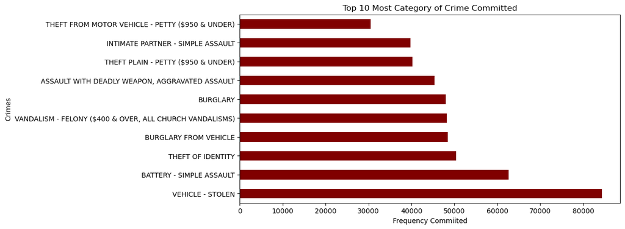

```python
#Top 10 most Category of Crimes Committed

eda('Crm Cd Desc','barh', 'Top 10 Most Category of Crime Committed', 'Frequency Commiited', 'Crimes',
    10, 5, 'maroon', 10)
```

###### From the top most committed crimes in Los Angeles, Vehicle Stealing leads the way, followed by Simple Assault and then Identity Theft. Your car is more likely to be stolen compared to any other crime in Los Angeles.

#### Time Series Analysis

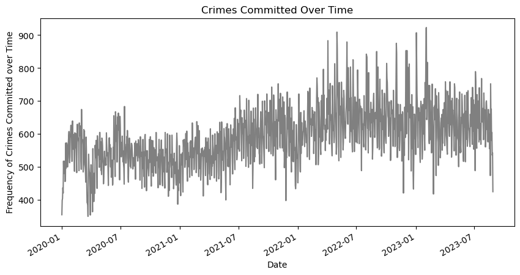

```python
#Frequency of Crimes Committed Daily over Time

eda('Date Rptd', 'line', 'Crimes Committed Over Time', 'Date', 'Frequency of Crimes Committed over Time',
    10, 5, 'gray')
```

###### The above graph depicts Crimes Reported/Committed Over Time since early 2020

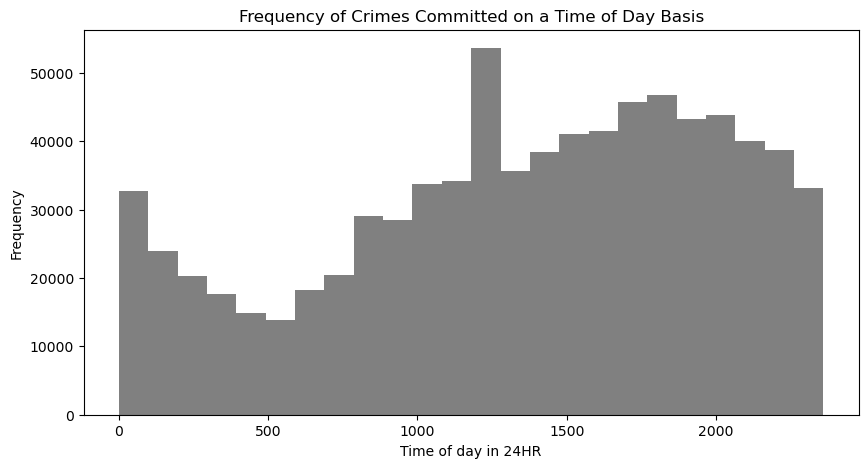

```python
#Frequency of Crimes Commited by Time of Day

data['TIME OCC'].plot(kind = 'hist', bins = 24, color='grey', figsize = (10 ,5));
plt.title("Frequency of Crimes Committed on a Time of Day Basis")
plt.xlabel("Time of day in 24HR")
plt.ylabel("Frequency")
```

###### You are more likely to be a victim of a crime in Los Angeles around midday as per the above graph showing the distribution of crimes committed on a timely basis on a 24 hour clock system.

#### Distribution of Crimes Committed per Victim Sex

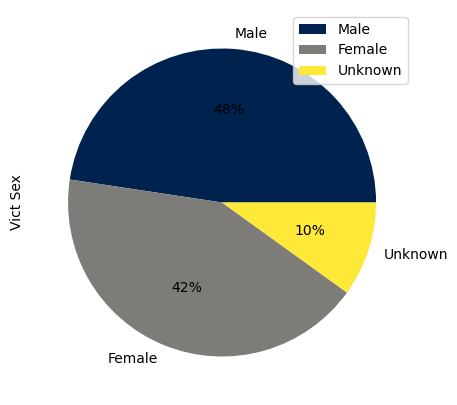

```python
#Pie Chart to represent Victims Gender

data['Vict Sex'].value_counts().plot(kind = 'pie', autopct='%1.0f%%', colormap='cividis', figsize = (15 ,5))

plt.legend()
```

###### Males represent the most victims with a 48% chunk with Women having a 42% representation while the Unknown are represented by just 10% (probably did not want to disclose their gender)

#### Distribution of Victim Descent

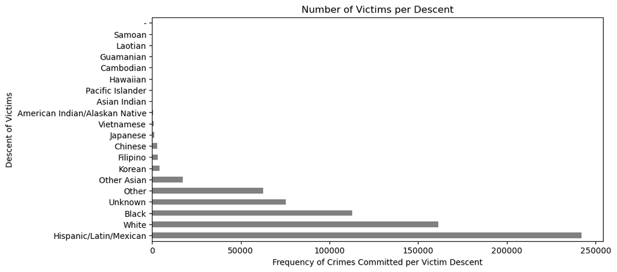

```python
eda('Vict Descent', 'barh', 'Number of Victims per Descent', 'Frequency of Crimes Committed per Victim Descent', 'Descent of Victims',
    10, 5, 'gray')
```

###### Hispanic/Latin/Mexicans are the most victims of crimes committed in LA, followed by Whites then Blacks. This means that most of the crime revolves around these three descents.

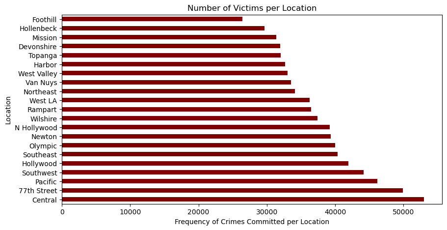

```python
eda('AREA NAME', 'barh', 'Number of Victims per Location', 'Frequency of Crimes Committed per Location', 'Location',
    10, 5, 'maroon')
```

###### The horizontal graph represents the distribution of crimes committed by Area.

> Central area reports most of the crime in the city, followed by 77th Street, Pacific, and the rest follows closely.

#### Distribution by Victim Age

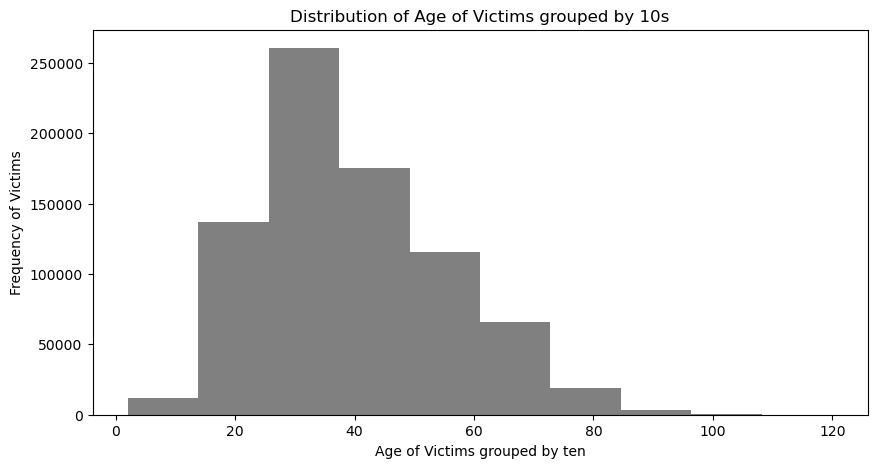

```python
#Histogram Distribution of Victims by age grouped in tens

data['Vict Age'].plot(kind = 'hist', bins = 10, color='grey', figsize = (10 ,5));
plt.title("Distribution of Age of Victims grouped by 10s")
plt.xlabel("Age of Victims grouped by ten")
plt.ylabel("Frequency of Victims")
```

###### You are more likely to be a victim of a crime committed in LA if you're between 30 and 40 years as per the distribution shown in the histogram, showing the distribution of victims age grouped in 10 years.

#### Distribution by Premises Crime Occurred - Top 10

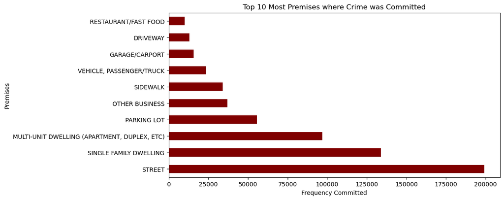

```python
#Grpah Distribution of Premises where the top most crimes occurred

eda('Premis Desc', 'barh', 'Top 10 Most Premises where Crime was Committed', 'Frequency Committed', 'Premises',
    10, 5, 'maroon', 10)
```

###### Most crimes in the city of Los Angeles are committed in the Streets, followed by homesteads of single-family dwellings, then multi-unit dwelling units, followed by parking lots as visualized in the horizontal graph above.

#### Weapons Used

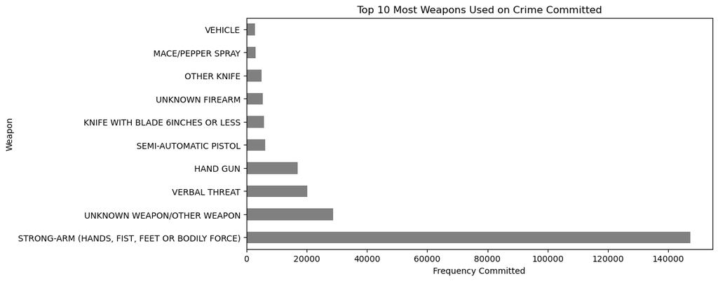

```python
#Distribution of Weapons Used on Crimes

eda('Weapon Desc', 'barh', 'Top 10 Most Weapons Used on Crime Committed', 'Frequency Committed', 'Weapon',
    10, 5, 'grey', 10)
```

###### Most criminals use their body as a weapon, i.e. hands, and feet, while the next weapon is unknown to victims, verbal threats follow in third while the use of handguns comes in fourth as the most used weapon to commit crime in LA.

#### Status of the Crime

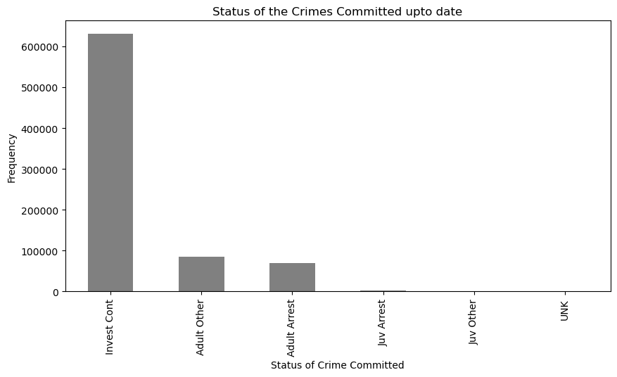

```python
#Status of the Crimes Committed upto date

eda('Status Desc', 'bar', 'Status of the Crimes Committed upto date', 'Status of Crime Committed', 'Frequency',
    10, 5, 'grey', 10)
```

###### Most crimes reported from the onset in early 2020 are still under investigation, with a huge gap between Arrests on both Adult Arrests and Juvenile Arrests and Investigations Continuing. Adults Arrested are significantly higher compared to Juvenile Arrested.